# linear

## Linear classifier: sklearn is a high-level library that abstracts away many of the details of the training process

In this code:

We first load the digits dataset, which is a set of 8x8 images of digits. We standardize the features using StandardScaler, which scales the features to have zero mean and unit variance. We split the data into a training set and a test set using train_test_split. We create a logistic regression classifier, which is a type of linear classifier, using LogisticRegression. We train the classifier on the training data using clf.fit. Finally, we print the accuracy of the classifier on the test set using clf.score.

Dataset:

Samples per class ~180

Samples total 1797

Features integers 0-16

```
(1797, 64)
```

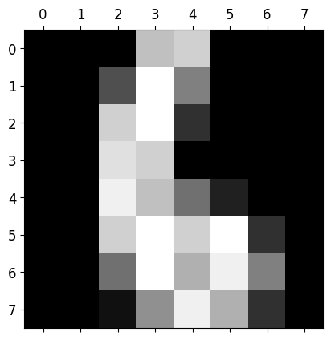

```python
#sklearn.datasets.load_digits
from sklearn.datasets import load_digits
digits = load_digits()
print(digits.data.shape)
(1797, 64)
import matplotlib.pyplot as plt
plt.gray()
plt.matshow(digits.images[6])

plt.show()
```

```python
from sklearn import datasets
from sklearn.model_selection import train_test_split
from sklearn.preprocessing import StandardScaler
from sklearn.linear_model import LogisticRegression

# Load the digits dataset
digits = datasets.load_digits()

# Standardize the features
scaler = StandardScaler()
X = scaler.fit_transform(digits.data)

# Use the digit labels as the target
y = digits.target

# Split the data into training and test sets
X_train, X_test, y_train, y_test = train_test_split(X, y, test_size=0.2, random_state=42)

# Create a logistic regression classifier (a type of linear classifier)
clf = LogisticRegression()

# Train the classifier
clf.fit(X_train, y_train)

# Print the accuracy on the test set
print(f'Test accuracy: {clf.score(X_test, y_test)*100:.2f}%')

from sklearn.metrics import log_loss
y_pred = clf.predict_proba(X_test)
print(f'Loss: {log_loss(y_test, y_pred)}')
```

```
Test accuracy: 97.22%
Loss: 0.10832094375944652
```

## Linear Classifier using PyTorch

This code does the same thing as your original code, but uses PyTorch instead of scikit-learn. It first loads and preprocesses the data, then defines a simple linear model (equivalent to logistic regression in this case), and finally trains the model and evaluates its accuracy on the test set. Note that PyTorch requires the data to be in the form of tensors, so we convert the data to tensors before training the model. Also, PyTorch doesn’t have a built-in function for calculating the accuracy, so we calculate it manually in the evaluation step. The CrossEntropyLoss function in PyTorch applies a softmax function to the output and then calculates the log loss, similar to what predict_proba does in scikit-learn.

```python
import torch
from torch import nn, optim
from torch.utils.data import DataLoader, TensorDataset
from sklearn import datasets
from sklearn.model_selection import train_test_split
from sklearn.preprocessing import StandardScaler

# Load the digits dataset
digits = datasets.load_digits()

# Standardize the features
scaler = StandardScaler()
X = scaler.fit_transform(digits.data)

# Use the digit labels as the target
y = digits.target

# Split the data into training and test sets
X_train, X_test, y_train, y_test = train_test_split(X, y, test_size=0.2, random_state=42)

# Convert to tensors
X_train = torch.tensor(X_train, dtype=torch.float32)
y_train = torch.tensor(y_train, dtype=torch.long)
X_test = torch.tensor(X_test, dtype=torch.float32)
y_test = torch.tensor(y_test, dtype=torch.long)

# Create dataloaders
train_data = TensorDataset(X_train, y_train)
test_data = TensorDataset(X_test, y_test)
train_loader = DataLoader(train_data, batch_size=32)
test_loader = DataLoader(test_data, batch_size=32)

# Define the model
model = nn.Linear(X_train.shape[1], len(torch.unique(y_train)))

# Define the loss and optimizer
criterion = nn.CrossEntropyLoss()
optimizer = optim.SGD(model.parameters(), lr=0.01)

# Train the model
for epoch in range(100):
    for inputs, labels in train_loader:
        optimizer.zero_grad()
        output = model(inputs)
        loss = criterion(output, labels)
        loss.backward()
        optimizer.step()

# Evaluate the model
correct = 0
total = 0
with torch.no_grad():
    for inputs, labels in test_loader:
        output = model(inputs)
        _, predicted = torch.max(output.data, 1)
        total += labels.size(0)
        correct += (predicted == labels).sum().item()

print(f'Test accuracy: {correct / total * 100:.2f}%')
```

```
Test accuracy: 95.83%
```